# HDS5101_final_vid

Klosowski Filip

2026-03-19

```r
library(tidyverse)

library(mice)
library(Hmisc)
library(VIM)
library(knitr)

set.seed(21490084)
```

# Question

To what extent do health-related variables influence marathon finish time, and how well can these variables be used to predict performance?

- Subset the full dataset to health-related variables
- Draw a random sample of 2,000 observations and treat the full dataset as a population proxy
- Explore and handle missing data using MICE
- Fit a series of predictive models:
  - simple linear regression using VO2 max only
  - adjusted linear regression
  - quadratic model for VO2 max
  - fuller multivariable model
  - interaction model with VO2 max and gender
- Compare models using RMSE, MAE and R-squared

# Full Data Set Exploration

```r
marathon_data_full <- read_csv("marathondata.csv")
marathon_data <- marathon_data_full %>%
  select(
    age,
    gender,
    resting_heart_rate_bpm,
    vo2_max,
    bmi,
    sleep_hours_avg,
    injury_count,
    nutrition_score,
    hydration_consistency,
    actual_finish_time_minutes
  ) %>%
  mutate(
    gender = as.factor(gender)
  )

names(marathon_data)
```

```
##  [1] "age"                        "gender"
##  [3] "resting_heart_rate_bpm"     "vo2_max"
##  [5] "bmi"                        "sleep_hours_avg"
##  [7] "injury_count"               "nutrition_score"
##  [9] "hydration_consistency"      "actual_finish_time_minutes"
```

```r
head(marathon_data, 10)
```

```
## # A tibble: 10 × 10
##      age gender resting_heart_rate_bpm vo2_max   bmi sleep_hours_avg
##    <dbl> <fct>                   <dbl>   <dbl> <dbl>           <dbl>
##  1    25 Male                       80    41.5  22.2             5
##  2    43 Female                     80    52.7  22.5             6
##  3    32 Female                     80    43.6  20.6             5.5
##  4    57 Male                       46    66.9  26.1             7.4
##  5    54 Female                     77    56.6  20.6             8.1
##  6    45 Male                       74    55.2  23.9             7.3
##  7    18 Female                     72    NA    23.3             6.2
##  8    51 Male                       80    NA    24.5             8.2
##  9    54 Male                       79    NA    25.2             6
## 10    28 Female                     75    56.9  21.1             7.6
## # ℹ 4 more variables: injury_count <dbl>, nutrition_score <dbl>,
## #   hydration_consistency <dbl>, actual_finish_time_minutes <dbl>
```

```r
dim(marathon_data)
```

```
## [1] 80000    10
```

# Sample Data

```r
set.seed(21490084)

sample_index <- sample(seq_len(nrow(marathon_data)), size = 2000)

marathon_data_sampled <- marathon_data[sample_index, ]
```

# Missing Data

```r
missing_prop_long <- marathon_data_sampled %>%
  summarise(across(everything(), ~ mean(is.na(.)))) %>%
  pivot_longer(
    cols = everything(),
    names_to = "variable",
    values_to = "prop_missing"
  ) %>%
  filter(prop_missing > 0) %>%
  arrange(desc(prop_missing))

missing_prop_long
```

```
## # A tibble: 5 × 2
##   variable                   prop_missing
##   <chr>                             <dbl>
## 1 vo2_max                           0.124
## 2 hydration_consistency             0.092
## 3 nutrition_score                   0.081
## 4 sleep_hours_avg                   0.05
## 5 actual_finish_time_minutes        0.021
```

**MICE**

```r
imputed_data <- mice(
  data = marathon_data_sampled,
  m = 5,
  method = "pmm",
  seed = 21490084,
  print = FALSE
)

marathon_data_complete <- complete(imputed_data, 1)
```

```r
marathon_data_population <- marathon_data %>%
  drop_na(
    actual_finish_time_minutes,
    vo2_max,
    age,
    gender,
    bmi,
    resting_heart_rate_bpm,
    sleep_hours_avg,
    nutrition_score,
    hydration_consistency
  )
```

**Model 1: VO2 max only LM**

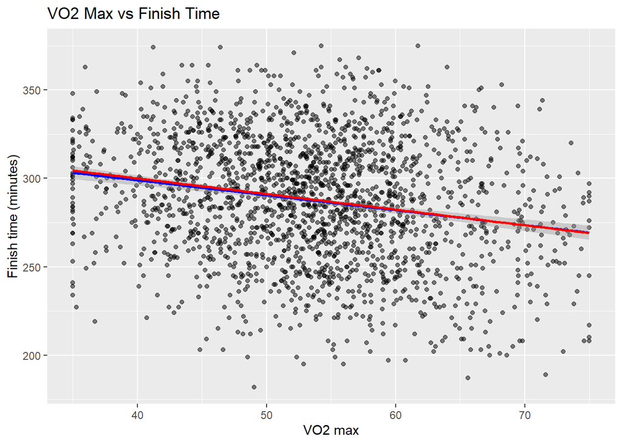

```r
model_1 <- lm(
  actual_finish_time_minutes ~ vo2_max,
  data = marathon_data_complete
)

model_1_population <- lm(
  actual_finish_time_minutes ~ vo2_max,
  data = marathon_data_population
)

ggplot(marathon_data_complete, aes(x = vo2_max, y = actual_finish_time_minutes)) +
  geom_point(alpha = 0.5) +
  geom_smooth(method = "lm", colour = "blue") +
  geom_smooth(
    data = marathon_data_population,
    aes(x = vo2_max, y = actual_finish_time_minutes),
    method = "lm",
    colour = "red"
  ) +
  labs(
    title = "VO2 Max vs Finish Time",
    x = "VO2 max",
    y = "Finish time (minutes)"
  )
```

```r
summary(model_1)
```

```
##
## Call:
## lm(formula = actual_finish_time_minutes ~ vo2_max, data = marathon_data_complete)
##
## Residuals:
##      Min       1Q   Median       3Q      Max
## -109.304  -24.104    0.921   24.808   94.432
##
## Coefficients:
##              Estimate Std. Error t value Pr(>|t|)
## (Intercept) 332.78508    4.87529  68.259   <2e-16 ***
## vo2_max      -0.84576    0.09001  -9.397   <2e-16 ***
## ---
## Signif. codes:  0 '***' 0.001 '**' 0.01 '*' 0.05 '.' 0.1 ' ' 1
##
## Residual standard error: 34.22 on 1998 degrees of freedom
## Multiple R-squared:  0.04232,    Adjusted R-squared:  0.04184
## F-statistic:  88.3 on 1 and 1998 DF,  p-value: < 2.2e-16
```

**Model 2: adjusted linear model**

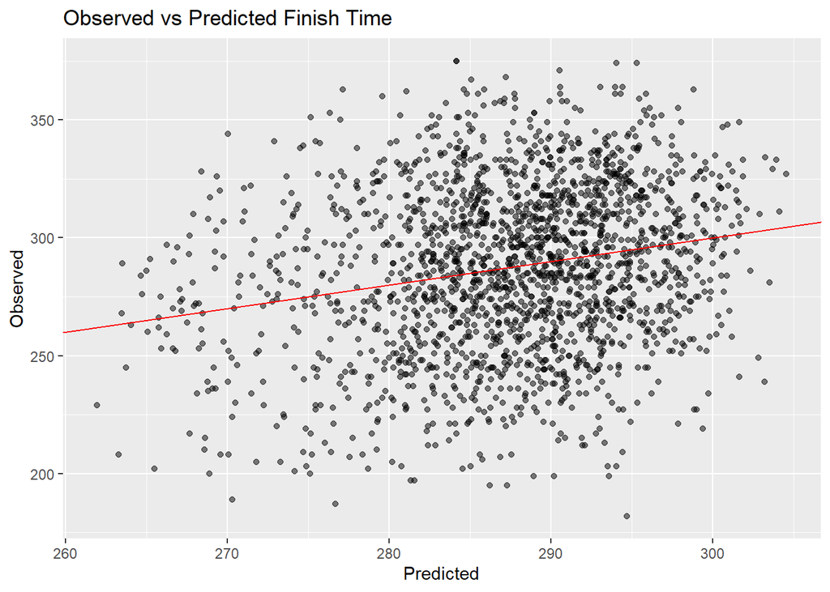

```r
model_2 <- lm(
  actual_finish_time_minutes ~ vo2_max + age + bmi + resting_heart_rate_bpm +
    sleep_hours_avg + nutrition_score,
  data = marathon_data_complete
)

plot_data_2 <- marathon_data_complete %>%
  mutate(predicted = predict(model_2))

ggplot(plot_data_2, aes(x = predicted, y = actual_finish_time_minutes)) +
  geom_point(alpha = 0.5) +
  geom_abline(slope = 1, intercept = 0, colour = "red") +
  labs(
    title = "Observed vs Predicted Finish Time",
    x = "Predicted",
    y = "Observed"
  )
```

```r
summary(model_2)
```

```
##
## Call:
## lm(formula = actual_finish_time_minutes ~ vo2_max + age + bmi +
##     resting_heart_rate_bpm + sleep_hours_avg + nutrition_score,
##     data = marathon_data_complete)
##
## Residuals:
##      Min       1Q   Median       3Q      Max
## -112.693  -24.112    1.135   24.931   90.846
##
## Coefficients:
##                         Estimate Std. Error t value Pr(>|t|)
## (Intercept)            295.73616   22.96278  12.879  < 2e-16 ***
## vo2_max                 -0.61857    0.14613  -4.233 2.41e-05 ***
## age                      0.02410    0.05693   0.423   0.6721
## bmi                      0.27710    0.30324   0.914   0.3609
## resting_heart_rate_bpm   0.36540    0.19119   1.911   0.0561 .
## sleep_hours_avg         -1.30312    0.76887  -1.695   0.0903 .
## nutrition_score         -0.15709    0.34636  -0.454   0.6502
## ---
## Signif. codes:  0 '***' 0.001 '**' 0.01 '*' 0.05 '.' 0.1 ' ' 1
##
## Residual standard error: 34.2 on 1993 degrees of freedom
## Multiple R-squared:  0.04601,    Adjusted R-squared:  0.04313
## F-statistic: 16.02 on 6 and 1993 DF,  p-value: < 2.2e-16
```

**Model 3: Quadratic Model**

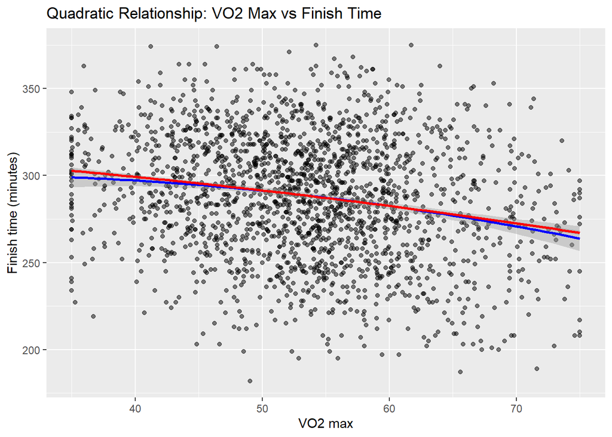

```r
model_3 <- lm(
  actual_finish_time_minutes ~ poly(vo2_max, 2),
  data = marathon_data_complete
)

model_3_population <- lm(
  actual_finish_time_minutes ~ poly(vo2_max, 2),
  data = marathon_data_population
)

ggplot(marathon_data_complete, aes(x = vo2_max, y = actual_finish_time_minutes)) +
  geom_point(alpha = 0.5) +
  stat_smooth(method = "lm", formula = y ~ poly(x, 2), colour = "blue") +
  stat_smooth(
    data = marathon_data_population,
    aes(x = vo2_max, y = actual_finish_time_minutes),
    method = "lm",
    formula = y ~ poly(x, 2),
    colour = "red"
  ) +
  labs(
    title = "Quadratic Relationship: VO2 Max vs Finish Time",
    x = "VO2 max",
    y = "Finish time (minutes)"
  )
```

```r
summary(model_3)
```

```
##
## Call:
## lm(formula = actual_finish_time_minutes ~ poly(vo2_max, 2), data = marathon_data_complete)
##
## Residuals:
##      Min       1Q   Median       3Q      Max
## -110.025  -23.930    1.099   24.945   94.272
##
## Coefficients:
##                    Estimate Std. Error t value Pr(>|t|)
## (Intercept)        287.5415     0.7648 375.984   <2e-16 ***
## poly(vo2_max, 2)1 -321.5732    34.2016  -9.402   <2e-16 ***
## poly(vo2_max, 2)2  -63.0314    34.2016  -1.843   0.0655 .
## ---
## Signif. codes:  0 '***' 0.001 '**' 0.01 '*' 0.05 '.' 0.1 ' ' 1
##
## Residual standard error: 34.2 on 1997 degrees of freedom
## Multiple R-squared:  0.04395,    Adjusted R-squared:  0.04299
## F-statistic:  45.9 on 2 and 1997 DF,  p-value: < 2.2e-16
```

**Model 4: fuller linear model including gender and hydration**

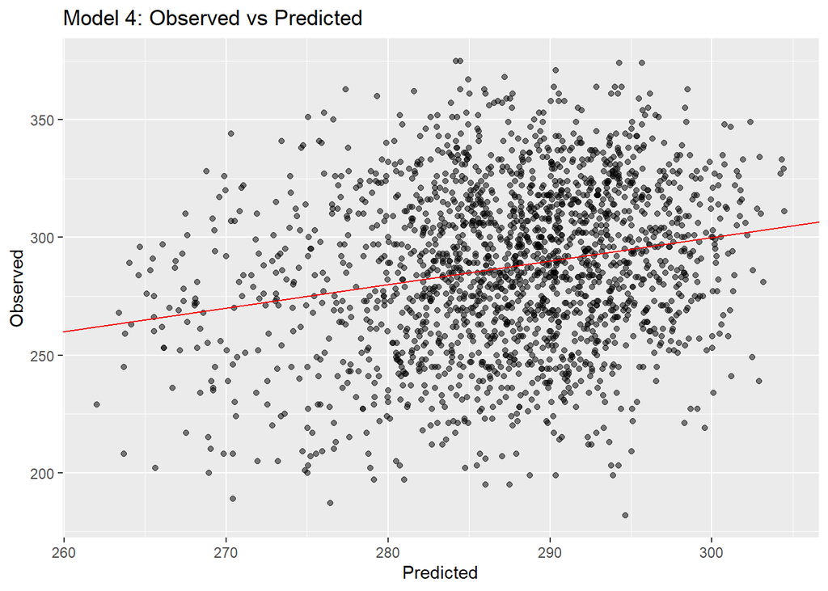

```r
model_4 <- lm(
  actual_finish_time_minutes ~ vo2_max + age + gender + bmi +
    resting_heart_rate_bpm + sleep_hours_avg + nutrition_score +
    hydration_consistency,
  data = marathon_data_complete
)

plot_data_4 <- marathon_data_complete %>%
  mutate(predicted = predict(model_4))

ggplot(plot_data_4, aes(x = predicted, y = actual_finish_time_minutes)) +
  geom_point(alpha = 0.5) +
  geom_abline(slope = 1, intercept = 0, colour = "red") +
  labs(
    title = "Model 4: Observed vs Predicted",
    x = "Predicted",
    y = "Observed"
  )
```

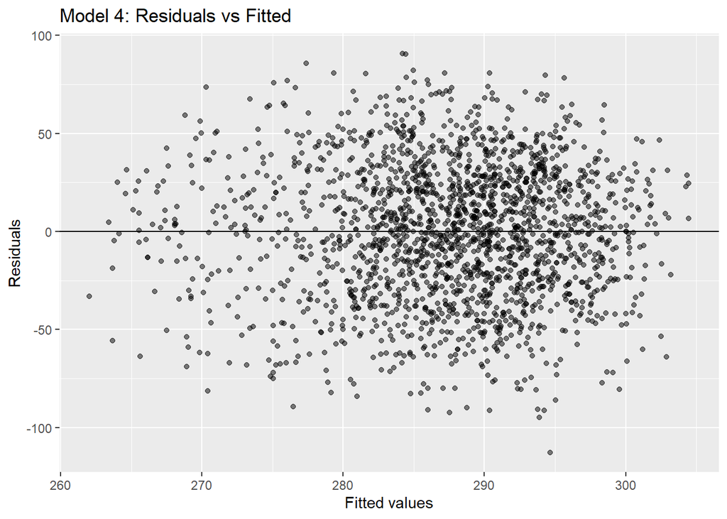

```r
plot_data_4 <- plot_data_4 %>%
  mutate(residuals = actual_finish_time_minutes - predicted)

ggplot(plot_data_4, aes(x = predicted, y = residuals)) +
  geom_point(alpha = 0.5) +
  geom_hline(yintercept = 0) +
  labs(
    title = "Model 4: Residuals vs Fitted",
    x = "Fitted values",
    y = "Residuals"
  )
```

```r
summary(model_4)
```

```
##
## Call:
## lm(formula = actual_finish_time_minutes ~ vo2_max + age + gender +
##     bmi + resting_heart_rate_bpm + sleep_hours_avg + nutrition_score +
##     hydration_consistency, data = marathon_data_complete)
##
## Residuals:
##      Min       1Q   Median       3Q      Max
## -112.659  -24.117    1.081   24.767   90.802
##
## Coefficients:
##                         Estimate Std. Error t value Pr(>|t|)
## (Intercept)            296.97929   23.17402  12.815  < 2e-16 ***
## vo2_max                 -0.61828    0.14624  -4.228 2.47e-05 ***
## age                      0.02501    0.05699   0.439   0.6608
## genderMale               0.45690    1.62652   0.281   0.7788
## genderNon-binary        -2.20920    4.24745  -0.520   0.6030
## bmi                      0.25096    0.31630   0.793   0.4276
## resting_heart_rate_bpm   0.36281    0.19136   1.896   0.0581 .
## sleep_hours_avg         -1.30790    0.76962  -1.699   0.0894 .
## nutrition_score         -0.15702    0.34658  -0.453   0.6506
## hydration_consistency   -0.10686    0.35885  -0.298   0.7659
## ---
## Signif. codes:  0 '***' 0.001 '**' 0.01 '*' 0.05 '.' 0.1 ' ' 1
##
## Residual standard error: 34.22 on 1990 degrees of freedom
## Multiple R-squared:  0.04625,    Adjusted R-squared:  0.04194
## F-statistic: 10.72 on 9 and 1990 DF,  p-value: < 2.2e-16
```

**Model 5: interaction model where the effect of vo2_max can differ by gender**

```r
model_5 <- lm(
  actual_finish_time_minutes ~ vo2_max * gender + age + bmi +
    resting_heart_rate_bpm + sleep_hours_avg + nutrition_score,
  data = marathon_data_complete
)

summary(model_5)
```

```
##
## Call:
## lm(formula = actual_finish_time_minutes ~ vo2_max * gender +
##     age + bmi + resting_heart_rate_bpm + sleep_hours_avg + nutrition_score,
##     data = marathon_data_complete)
##
## Residuals:
##      Min       1Q   Median       3Q      Max
## -112.445  -24.128    1.205   24.691   91.114
##
## Coefficients:
##                           Estimate Std. Error t value Pr(>|t|)
## (Intercept)              301.42626   23.63793  12.752  < 2e-16 ***
## vo2_max                   -0.71000    0.17511  -4.055 5.22e-05 ***
## genderMale                -9.94437    9.96992  -0.997   0.3187
## genderNon-binary           2.26766   26.15220   0.087   0.9309
## age                        0.02753    0.05708   0.482   0.6296
## bmi                        0.25496    0.31623   0.806   0.4202
## resting_heart_rate_bpm     0.35742    0.19142   1.867   0.0620 .
## sleep_hours_avg           -1.29280    0.76954  -1.680   0.0931 .
## nutrition_score           -0.16436    0.34677  -0.474   0.6356
## vo2_max:genderMale         0.19420    0.18396   1.056   0.2913
## vo2_max:genderNon-binary  -0.08104    0.47363  -0.171   0.8642
## ---
## Signif. codes:  0 '***' 0.001 '**' 0.01 '*' 0.05 '.' 0.1 ' ' 1
##
## Residual standard error: 34.22 on 1989 degrees of freedom
## Multiple R-squared:  0.04681,    Adjusted R-squared:  0.04202
## F-statistic: 9.768 on 10 and 1989 DF,  p-value: 4.224e-16
```

```r
pooled_model_1 <- pool(
  with(imputed_data, lm(actual_finish_time_minutes ~ vo2_max))
)

pooled_model_2 <- pool(
  with(imputed_data, lm(actual_finish_time_minutes ~ vo2_max + age + bmi +
    resting_heart_rate_bpm + sleep_hours_avg + nutrition_score))
)

pooled_model_3 <- pool(
  with(imputed_data, lm(actual_finish_time_minutes ~ poly(vo2_max, 2)))
)

pooled_model_4 <- pool(
  with(imputed_data, lm(actual_finish_time_minutes ~ vo2_max + age + gender +
    bmi + resting_heart_rate_bpm + sleep_hours_avg + nutrition_score +
    hydration_consistency))
)

pooled_model_5 <- pool(
  with(imputed_data, lm(actual_finish_time_minutes ~ vo2_max * gender + age +
    bmi + resting_heart_rate_bpm + sleep_hours_avg + nutrition_score))
)

summary(pooled_model_1)
```

```
##          term    estimate  std.error statistic       df       p.value
## 1 (Intercept) 333.7183965 5.09566385 65.490662 438.2387 1.877812e-228
## 2     vo2_max  -0.8589109 0.09316481 -9.219263 610.8332  4.787984e-19
```

```r
summary(pooled_model_2)
```

```
##                     term     estimate   std.error  statistic        df
## 1            (Intercept) 293.63967216 23.60570714 12.4393508  704.0615
## 2                vo2_max  -0.63383977  0.15190310 -4.1726584  555.2501
## 3                    age   0.04168214  0.05859155  0.7114018  711.9212
## 4                    bmi   0.38326488  0.31114415  1.2317920  774.7616
## 5 resting_heart_rate_bpm   0.35510395  0.19359939  1.8342204 1405.1049
## 6        sleep_hours_avg  -1.26296550  0.78909818 -1.6005176  671.6466
## 7        nutrition_score  -0.06978592  0.36355522 -0.1919541  349.4252
##        p.value
## 1 2.977426e-32
## 2 3.493816e-05
## 3 4.770683e-01
## 4 2.184005e-01
## 5 6.683265e-02
## 6 1.099540e-01
## 7 8.478897e-01
```

```r
summary(pooled_model_3)
```

```
##                term   estimate std.error  statistic        df      p.value
## 1       (Intercept)  287.74160   0.78773 365.279463  663.9801 0.000000e+00
## 2 poly(vo2_max, 2)1 -325.61219  34.83917  -9.346154 1054.1236 5.256950e-20
## 3 poly(vo2_max, 2)2  -59.22129  34.56964  -1.713101 1455.1514 8.690697e-02
```

```r
summary(pooled_model_4)
```

```
##                      term     estimate   std.error  statistic        df
## 1             (Intercept) 294.56152799 23.84576452 12.3527819  649.8939
## 2                 vo2_max  -0.63247999  0.15211901 -4.1577972  543.7152
## 3                     age   0.04270861  0.05867859  0.7278398  701.4305
## 4              genderMale   0.66999711  1.62836028  0.4114551 1914.6397
## 5        genderNon-binary  -1.41689166  4.31512279 -0.3283549 1165.6770
## 6                     bmi   0.34589634  0.32291229  1.0711774  963.8183
## 7  resting_heart_rate_bpm   0.35418688  0.19386631  1.8269646 1371.7252
## 8         sleep_hours_avg  -1.26389670  0.78974406 -1.6003877  674.2935
## 9         nutrition_score  -0.07009339  0.36440598 -0.1923497  333.4669
## 10  hydration_consistency  -0.06657812  0.36467727 -0.1825672 1252.2166
##         p.value
## 1  1.229279e-31
## 2  3.732978e-05
## 3  4.669545e-01
## 4  6.807849e-01
## 5  7.427023e-01
## 6  2.843578e-01
## 7  6.792229e-02
## 8  1.099810e-01
## 9  8.475854e-01
## 10 8.551672e-01
```

```r
summary(pooled_model_5)
```

```
##                        term     estimate   std.error  statistic        df
## 1               (Intercept) 299.23895106 24.23008527 12.3498926  791.7608
## 2                   vo2_max  -0.72164164  0.18120573 -3.9824438  637.8877
## 3                genderMale  -9.77388876 10.32176837 -0.9469200  603.5199
## 4          genderNon-binary   7.80980580 27.04946912  0.2887231  845.5768
## 5                       age   0.04556179  0.05888612  0.7737271  642.7141
## 6                       bmi   0.34759564  0.32244343  1.0780050 1006.4549
## 7    resting_heart_rate_bpm   0.34832830  0.19358526  1.7993535 1467.0202
## 8           sleep_hours_avg  -1.26377013  0.78910167 -1.6015302  693.0710
## 9           nutrition_score  -0.07043477  0.36593447 -0.1924792  300.0041
## 10       vo2_max:genderMale   0.19510883  0.19051763  1.0240986  585.0767
## 11 vo2_max:genderNon-binary  -0.16666026  0.48554962 -0.3432404 1043.3616
##         p.value
## 1  3.613593e-32
## 2  7.606543e-05
## 3  3.440585e-01
## 4  7.728641e-01
## 5  4.393767e-01
## 6  2.812898e-01
## 7  7.216822e-02
## 8  1.097152e-01
## 9  8.474971e-01
## 10 3.062120e-01
## 11 7.314867e-01
```

```r
get_metrics <- function(model, data, model_name) {
  predicted <- predict(model, newdata = data)
  rmse <- sqrt(mean((data$actual_finish_time_minutes - predicted)^2))
  mae <- mean(abs(data$actual_finish_time_minutes - predicted))
  r_squared <- cor(data$actual_finish_time_minutes, predicted)^2

  data.frame(
    Model = model_name,
    R_squared = r_squared,
    RMSE = rmse,
    MAE = mae
  )
}
```

```r
sample_results <- bind_rows(
  get_metrics(model_1, marathon_data_complete, "Model 1: VO2 max only"),
  get_metrics(model_2, marathon_data_complete, "Model 2: Adjusted linear"),
  get_metrics(model_3, marathon_data_complete, "Model 3: Quadratic VO2 max"),
  get_metrics(model_4, marathon_data_complete, "Model 4: Full linear"),
  get_metrics(model_5, marathon_data_complete, "Model 5: VO2 max by gender")
)

sample_results
```

```
##                        Model  R_squared     RMSE      MAE
## 1      Model 1: VO2 max only 0.04232233 34.20501 27.76944
## 2   Model 2: Adjusted linear 0.04600569 34.13917 27.73359
## 3 Model 3: Quadratic VO2 max 0.04394834 34.17596 27.76697
## 4       Model 4: Full linear 0.04625033 34.13479 27.73191
## 5 Model 5: VO2 max by gender 0.04681115 34.12475 27.73316
```

```r
kable(sample_results, digits = 3)
```

| Model | R_squared | RMSE | MAE |
| --- | --- | --- | --- |
| Model 1: VO2 max only | 0.042 | 34.205 | 27.769 |
| Model 2: Adjusted linear | 0.046 | 34.139 | 27.734 |
| Model 3: Quadratic VO2 max | 0.044 | 34.176 | 27.767 |
| Model 4: Full linear | 0.046 | 34.135 | 27.732 |
| Model 5: VO2 max by gender | 0.047 | 34.125 | 27.733 |

```r
population_results <- bind_rows(
  get_metrics(model_1, marathon_data_population, "Model 1: VO2 max only"),
  get_metrics(model_2, marathon_data_population, "Model 2: Adjusted linear"),
  get_metrics(model_3, marathon_data_population, "Model 3: Quadratic VO2 max"),
  get_metrics(model_4, marathon_data_population, "Model 4: Full linear"),
  get_metrics(model_5, marathon_data_population, "Model 5: VO2 max by gender")
)

population_results
```

```
##                        Model  R_squared     RMSE      MAE
## 1      Model 1: VO2 max only 0.04998688 32.78769 26.62912
## 2   Model 2: Adjusted linear 0.05101554 32.76860 26.62607
## 3 Model 3: Quadratic VO2 max 0.04953093 32.79414 26.63368
## 4       Model 4: Full linear 0.05053067 32.77706 26.63162
## 5 Model 5: VO2 max by gender 0.04987083 32.78838 26.63949
```

```r
kable(population_results, digits = 3)
```

| Model | R_squared | RMSE | MAE |
| --- | --- | --- | --- |
| Model 1: VO2 max only | 0.050 | 32.788 | 26.629 |
| Model 2: Adjusted linear | 0.051 | 32.769 | 26.626 |
| Model 3: Quadratic VO2 max | 0.050 | 32.794 | 26.634 |
| Model 4: Full linear | 0.051 | 32.777 | 26.632 |
| Model 5: VO2 max by gender | 0.050 | 32.788 | 26.639 |

# plots

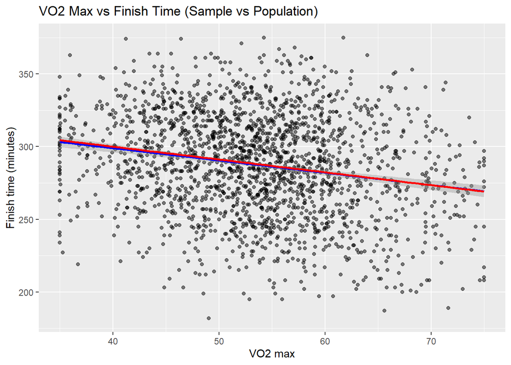

```r
ggplot(marathon_data_complete, aes(x = vo2_max, y = actual_finish_time_minutes)) +
  geom_point(alpha = 0.5) +
  geom_smooth(method = "lm", colour = "blue") +
  geom_smooth(
    data = marathon_data_population,
    aes(x = vo2_max, y = actual_finish_time_minutes),
    method = "lm",
    colour = "red"
  ) +
  labs(
    title = "VO2 Max vs Finish Time (Sample vs Population)",
    x = "VO2 max",
    y = "Finish time (minutes)"
  )
```